# Smooth spline estimator example

Washington University in St. Louis, University College

12/6/2021

## 1.1 Motivation and Goals

Multiple and generalized nonparametric regression models are powerful extensions of generalized linear models that can be used to estimate unknown functional relationships between a collection of predictors X1,…,Xp and an exponential family response variable Y. In R, several options exist for fitting such models. This document focuses on the gam function (in the mgcv package) and the gsm function (in the npreg package), both of which use a regression spline approach for the function estimation. This document provides examples that illustrate how to use the gam and gsm functions.

1.2 `gam` (Generalized Additive Model) Function (mgcv Package)

```
Syntax:

gam(formula,family=gaussian(),data=list(),weights=NULL,subset=NULL,
        na.action,offset=NULL,method="GCV.Cp",
        optimizer=c("outer","newton"),control=list(),scale=0,
        select=FALSE,knots=NULL,sp=NULL,min.sp=NULL,H=NULL,gamma=1,
        fit=TRUE,paraPen=NULL,G=NULL,in.out,drop.unused.
```

1.3 `gsm` (Generalized Smoothed Model) Function (npreg Package)

```
Syntax:

gsm(formula, family = gaussian, data, weights, types = NULL, tprk = TRUE,
        knots = NULL, update = TRUE, spar = NULL, lambda = NULL, control = list(),
        method = c("GCV", "OCV", "GACV", "ACV", "PQL", "AIC", "BIC"))

Or you could use the sm function for Gaussian data:

sm(formula, data, weights, types = NULL, tprk = TRUE, knots = NULL,
      update = TRUE, df, spar = NULL, lambda = NULL, control = list(),
      method = c("GCV", "OCV", "GACV", "ACV", "REML", "ML", "AIC", "BIC"))
The sm function has the benefit of more tuning methods and more efficient computational algorithms.
```

### 1.4 Comparison of Approaches

#### Overview

The gam and gsm functions differ in a variety of ways. Some key differences include:

- The formula specification. The gam function uses specialized syntax, whereas the gsm function uses the standard formula syntax, e.g., as used in the lm and glm functions.

*The types specification.*

The gam function requires the user to specify the smoother type within the formula specification via the arguments to the s function. The gsm function allows the user the input the smoother types separately via the types argument. Otherwise, the gsm function will infer the smoother type from the variable’s class, e.g., numeric class ↔︎ cubic spline, factor class ↔︎ nominal spline, and ordered class ↔︎ ordinal spline.

*The knots specification.*

The gam function requires the user to specify the knots within the formula specification via the arguments to the s function. The gsm function allows the user the input the knots separately via the knots argument. Otherwise, the gsm function will use a random sample of knots.

The gam function has more options avaiable for response variables, whereas the gsm function has more options avaiable for smoothing parameter selection.

Both functions offer some similar smoothers (e.g., cubic smoothing splines), as well as some unique smoothers, e.g., soap film smoothers in the gam function or ordinal smoothers in the gsm function.

## Example 1: Prestige by Income and Education (Gaussian)

### Overview of Data

The `Prestige` dataset (from the car package) contains the prestige of n=102 Canadian occupations from 1971, as well as the average income and education level of the occupation. We will use a multiple nonparametric regression model to model presitge as a function of income and education.

First, let’s load the data and visualize the relationship between income (X1), education (X2), and prestige (Y).

```r
data(Prestige)
head(Prestige)
```

```
##                     education income women prestige census type
## gov.administrators      13.11  12351 11.16     68.8   1113 prof
## general.managers        12.26  25879  4.02     69.1   1130 prof
## accountants             12.77   9271 15.70     63.4   1171 prof
## purchasing.officers     11.42   8865  9.11     56.8   1175 prof
## chemists                14.62   8403 11.68     73.5   2111 prof
## physicists              15.64  11030  5.13     77.6   2113 prof
```

[interactive chart not shown]

Note: the marginal relationship between prestige and income looks non-linear, whereas the marginal relationship between prestige and education looks mostly linear.

### Analyses and Results: gam Function

*Model Fitting*

R code to fit additive and interaction models with `gam` function:

```r
# additive model (using default number of knots for each predictor)
add.gam <- gam(prestige ~ s(income, bs = "cr") + s(education, bs = "cr"),
               data = Prestige)
add.gam
```

```
##
## Family: gaussian
## Link function: identity
##
## Formula:
## prestige ~ s(income, bs = "cr") + s(education, bs = "cr")
##
## Estimated degrees of freedom:
## 3.00 3.15  total = 7.15
##
## GCV score: 51.98404
```

#### Interaction model:

```r
# interaction model (using default number of knots for each predictor)
int.gam <- gam(prestige ~ s(income, bs = "cr") + s(education, bs = "cr")
               + ti(income, education, bs = c("cr", "cr")), data = Prestige)
int.gam
```

```
##
## Family: gaussian
## Link function: identity
##
## Formula:
## prestige ~ s(income, bs = "cr") + s(education, bs = "cr") + ti(income,
##     education, bs = c("cr", "cr"))
##
## Estimated degrees of freedom:
## 2.07 3.08 2.00  total = 8.16
##
## GCV score: 50.43404
```

*Model Summary*

R code to summarize the fit models:

```r
summary(add.gam)
```

```
##
## Family: gaussian
## Link function: identity
##
## Formula:
## prestige ~ s(income, bs = "cr") + s(education, bs = "cr")
##
## Parametric coefficients:
##             Estimate Std. Error t value Pr(>|t|)
## (Intercept)  46.8333     0.6884   68.03   <2e-16 ***
## ---
## Signif. codes:  0 '***' 0.001 '**' 0.01 '*' 0.05 '.' 0.1 ' ' 1
##
## Approximate significance of smooth terms:
##                edf Ref.df     F p-value
## s(income)    2.996  3.604 16.68  <2e-16 ***
## s(education) 3.154  3.913 39.22  <2e-16 ***
## ---
## Signif. codes:  0 '***' 0.001 '**' 0.01 '*' 0.05 '.' 0.1 ' ' 1
##
## R-sq.(adj) =  0.837   Deviance explained = 84.7%
## GCV = 51.984  Scale est. = 48.34     n = 102
```

```r
# summarize interaction model
summary(int.gam)
```

```
##
## Family: gaussian
## Link function: identity
##
## Formula:
## prestige ~ s(income, bs = "cr") + s(education, bs = "cr") + ti(income,
##     education, bs = c("cr", "cr"))
##
## Parametric coefficients:
##             Estimate Std. Error t value Pr(>|t|)
## (Intercept)   48.997      1.055   46.45   <2e-16 ***
## ---
## Signif. codes:  0 '***' 0.001 '**' 0.01 '*' 0.05 '.' 0.1 ' ' 1
##
## Approximate significance of smooth terms:
##                        edf Ref.df      F  p-value
## s(income)            2.074  2.543 20.252 2.11e-07 ***
## s(education)         3.083  3.875 41.372  < 2e-16 ***
## ti(income,education) 1.998  2.308  3.426   0.0299 *
## ---
## Signif. codes:  0 '***' 0.001 '**' 0.01 '*' 0.05 '.' 0.1 ' ' 1
##
## R-sq.(adj) =  0.843   Deviance explained = 85.4%
## GCV = 50.434  Scale est. = 46.402    n = 102
```

*Model Comparison*

Compare additive and interaction models:

```r
# pseudo F test of interaction effect
sse.dif <- add.gam$deviance - int.gam$deviance
df.dif <- sum(int.gam$edf1) - sum(add.gam$edf1)
Fstat <- (sse.dif / df.dif) / int.gam$sig2
pvalue <- 1 - pf(Fstat, df1 = df.dif, df2 = nrow(Prestige) - sum(int.gam$edf))
c(Fstat, pvalue)
```

```
## [1] 4.10954059 0.03805908
```

```r
# analysis of deviance table (gam)
anova(add.gam, int.gam, test = "F")
```

```
## Analysis of Deviance Table
##
## Model 1: prestige ~ s(income, bs = "cr") + s(education, bs = "cr")
## Model 2: prestige ~ s(income, bs = "cr") + s(education, bs = "cr") + ti(income,
##     education, bs = c("cr", "cr"))
##   Resid. Df Resid. Dev     Df Deviance      F  Pr(>F)
## 1    93.483     4585.1
## 2    92.274     4354.5 1.2089   230.53 4.1095 0.03811 *
## ---
## Signif. codes:  0 '***' 0.001 '**' 0.01 '*' 0.05 '.' 0.1 ' ' 1
```

*Plot Results*

Plot results for additive model:

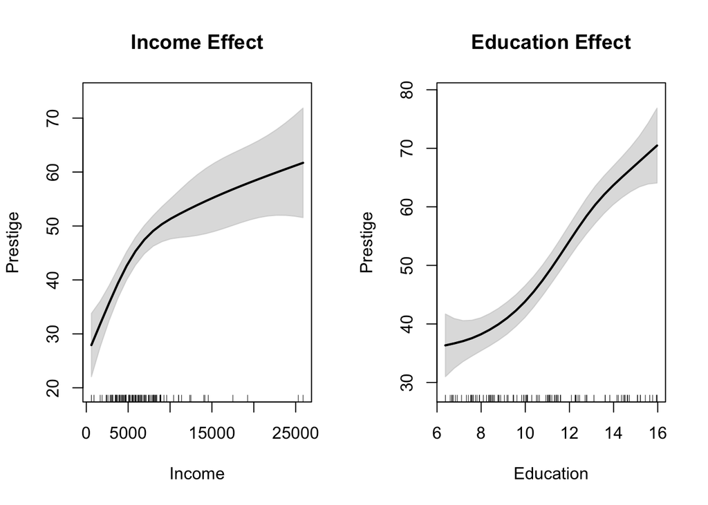

```r
# setup 1 x 2 subplots
par(mfrow = c(1,2))

# get predictor sequences
xrng <- list(income = range(Prestige$income),
             education = range(Prestige$education))
inc.seq <- seq(xrng$income[1], xrng$income[2], length.out = 25)
edu.seq <- seq(xrng$education[1], xrng$education[2], length.out = 25)

# main effect of income
newdata <- data.frame(income = inc.seq, education = mean(Prestige$education))
yhat.inc <- predict(add.gam, newdata = newdata, se.fit = TRUE)
plotci(inc.seq, yhat.inc$fit, yhat.inc$se.fit,
       xlab = "Income", ylab = "Prestige",
       main = "Income Effect")
rug(Prestige$income)

# main effect of education
newdata <- data.frame(income = mean(Prestige$income), education = edu.seq)
yhat.edu <- predict(add.gam, newdata = newdata, se.fit = TRUE)
plotci(edu.seq, yhat.edu$fit, yhat.edu$se.fit,
       xlab = "Education", ylab = "Prestige",
       main = "Education Effect")
rug(Prestige$education)
```

Plot results for interaction model:

```r
# setup 2 x 2 subplots
par(mfrow = c(2,2))

# quantiles of education
labs <- c("Low", "Low-Med", "Med-High", "High")
probs <- seq(0.2, 0.8, by = 0.2)
qvals <- unname(quantile(Prestige$education, probs = probs))
qvals
```

```
## [1]  8.128  9.708 11.172 13.620
```

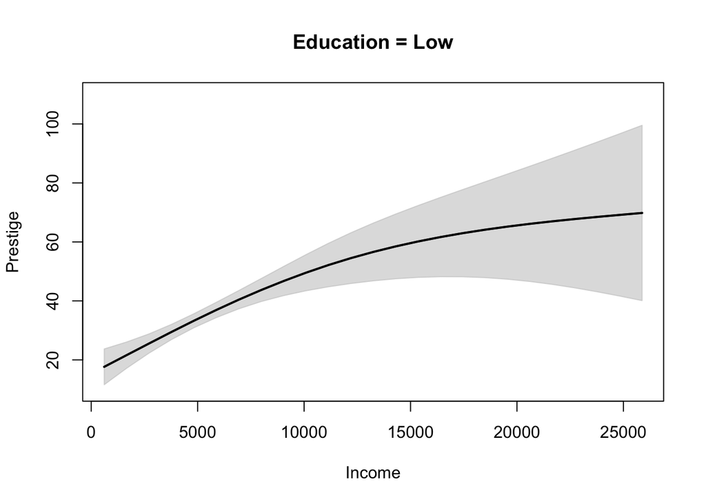

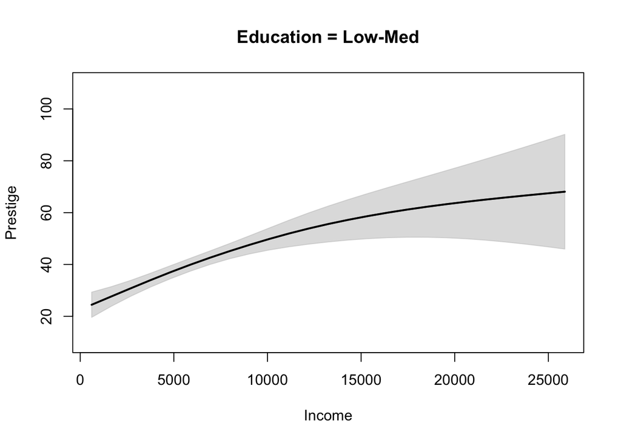

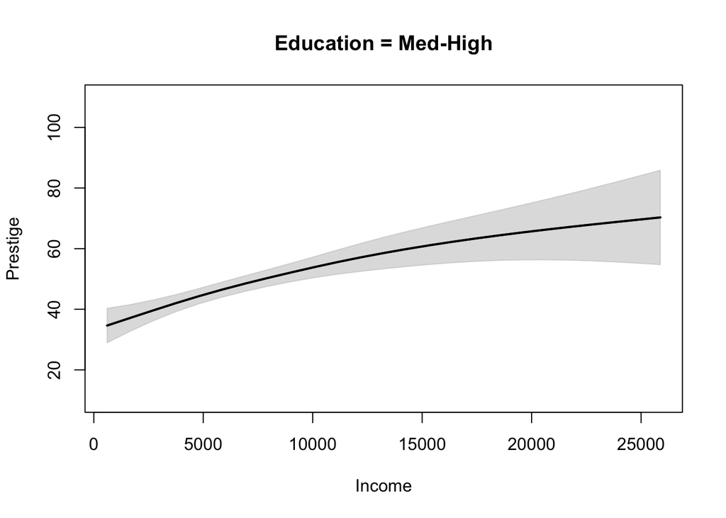

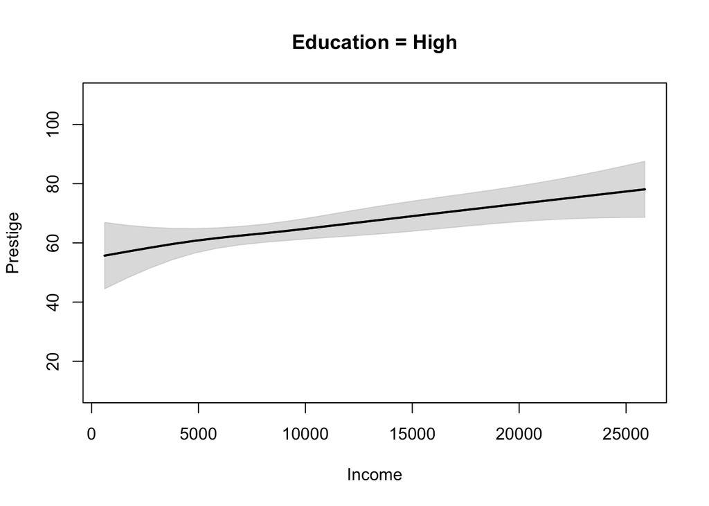

```r
# plot prestige ~ income at different education levels
for(j in 1:4){
  newdata <- data.frame(income = inc.seq, education = qvals[j])
  yhat <- predict(int.gam, newdata, se.fit = TRUE)
  plotci(inc.seq, yhat$fit, yhat$se.fit, ylim = c(10, 110),
         xlab = "Income", ylab = "Prestige",
         main = paste0("Education = ", labs[j]))
}
```

Surface plots for additive and interaction models:

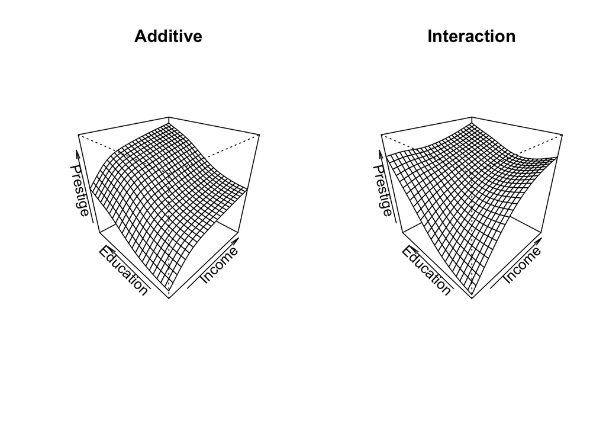

```r
# get predictions (for visualization)
inc.seq <- seq(xrng$income[1], xrng$income[2], length.out = 25)
edu.seq <- seq(xrng$education[1], xrng$education[2], length.out = 25)
newdata <- expand.grid(income = inc.seq, education = edu.seq)
yhat.add <- predict(add.gam, newdata)
yhat.int <- predict(int.gam, newdata)

# plot results
library(lattice)
par(mfrow = c(1,2))
persp(x = inc.seq, y = edu.seq, z = matrix(yhat.add, 25, 25),
      theta = -45, phi = 30, xlab = "Income", ylab = "Education",
      zlab = "Prestige", main = "Additive", zlim = c(10, 90))
persp(x = inc.seq, y = edu.seq, z = matrix(yhat.int, 25, 25),
      theta = -45, phi = 30, xlab = "Income", ylab = "Education",
      zlab = "Prestige", main = "Interaction", zlim = c(10, 90))
```

### Analyses and Results: gsm Function

*Model Fitting*

R code to fit additive and interaction models with gsm function (using all n=102 data points as knots):

```r
# additive model (using all knots)
add.gsm <- gsm(prestige ~ income + education, data = Prestige, knots = 102)
add.gsm
```

```
##
## Call:
## gsm(formula = prestige ~ income + education, data = Prestige,
##     knots = 102)
##
## Smoothing Parameter:  spar = 1   lambda = 0.9999995
## Equivalent Degrees of Freedom (Df):  7.531583
## Penalized Criterion (deviance):  4565.108
## Generalized Cross-Validation (GCV):  52.17687
```

```r
# interaction model (using all knots)
int.gsm <- gsm(prestige ~ income * education, data = Prestige, knots = 102)
int.gsm
```

```
##
## Call:
## gsm(formula = prestige ~ income * education, data = Prestige,
##     knots = 102)
##
## Smoothing Parameter:  spar = 0.9631002   lambda = 0.541264
## Equivalent Degrees of Freedom (Df):  8.22188
## Penalized Criterion (deviance):  4377.092
## Generalized Cross-Validation (GCV):  50.76715
```

*Model Summary*

R code to summarize the fit models:

```r
# summarize additive model
summary(add.gsm)
```

```
##
## Call:
## gsm(formula = prestige ~ income + education, data = Prestige,
##     knots = 102)
##
## Residuals:
##      Min       1Q   Median       3Q      Max
## -15.2811  -4.6473   0.8965   3.7966  18.2977
##
## Approx. Signif. of Parametric Effects:
##             Estimate Std. Error t value  Pr(>|t|)
## (Intercept)    55.25      1.731  31.928 0.000e+00 ***
## income         33.86      6.003   5.640 1.761e-07 ***
## education      33.82      4.386   7.711 1.251e-11 ***
## ---
## Signif. codes:  0 '***' 0.001 '**' 0.01 '*' 0.05 '.' 0.1 ' ' 1
##
## Approx. Signif. of Nonparametric Effects:
##                  Df Sum Sq Mean Sq F value    Pr(>F)
## s(income)     2.299  894.7  389.16   8.053 0.0003152 ***
## s(education)  2.452  361.5  147.46   3.052 0.0418193   *
## Residuals    94.468 4565.1   48.32
## ---
## Signif. codes:  0 '***' 0.001 '**' 0.01 '*' 0.05 '.' 0.1 ' ' 1
##
## Dispersion Parameter: 48.32,   Deviance Explained: 0.8473
##   Multiple R-squared: 0.8474,   Adjusted R-squared: 0.8367
```

```r
# summarize interaction model
summary(int.gsm)
```

```
##
## Call:
## gsm(formula = prestige ~ income * education, data = Prestige,
##     knots = 102)
##
## Residuals:
##      Min       1Q   Median       3Q      Max
## -14.8121  -4.5071   0.9162   4.2439  19.3760
##
## Approx. Signif. of Parametric Effects:
##                  Estimate Std. Error t value  Pr(>|t|)
## (Intercept)         61.19      2.575  23.766 0.000e+00 ***
## income              39.41      8.200   4.807 5.825e-06 ***
## education           24.12      8.553   2.820 5.854e-03  **
## income:education   -62.59     28.195  -2.220 2.883e-02   *
## ---
## Signif. codes:  0 '***' 0.001 '**' 0.01 '*' 0.05 '.' 0.1 ' ' 1
##
## Approx. Signif. of Nonparametric Effects:
##                          Df  Sum Sq Mean Sq F value   Pr(>F)
## s(income)            0.8165   45.74   56.02   1.200 0.276093
## s(education)         2.3423  621.39  265.29   5.684 0.002963 **
## s(income:education)  3.9008  352.39   90.34   1.935 0.112620
## Residuals           93.7781 4377.09   46.67
## ---
## Signif. codes:  0 '***' 0.001 '**' 0.01 '*' 0.05 '.' 0.1 ' ' 1
##
## Dispersion Parameter: 46.67,   Deviance Explained: 0.8536
##   Multiple R-squared: 0.8537,   Adjusted R-squared: 0.8423
```

*Model Comparison*

Compare additive and interaction models:

```r
# pseudo F test of interaction effect
sse.dif <- add.gsm$deviance - int.gsm$deviance
df.dif <- int.gsm$df - add.gsm$df
Fstat <- (sse.dif / df.dif) / int.gsm$dispersion
pvalue <- 1 - pf(Fstat, df1 = df.dif, df2 = nrow(Prestige) - int.gsm$df)
c(Fstat, pvalue)
```

```
## [1] 5.83547586 0.02811479
```

*Plot Results*

Plot results for additive model:

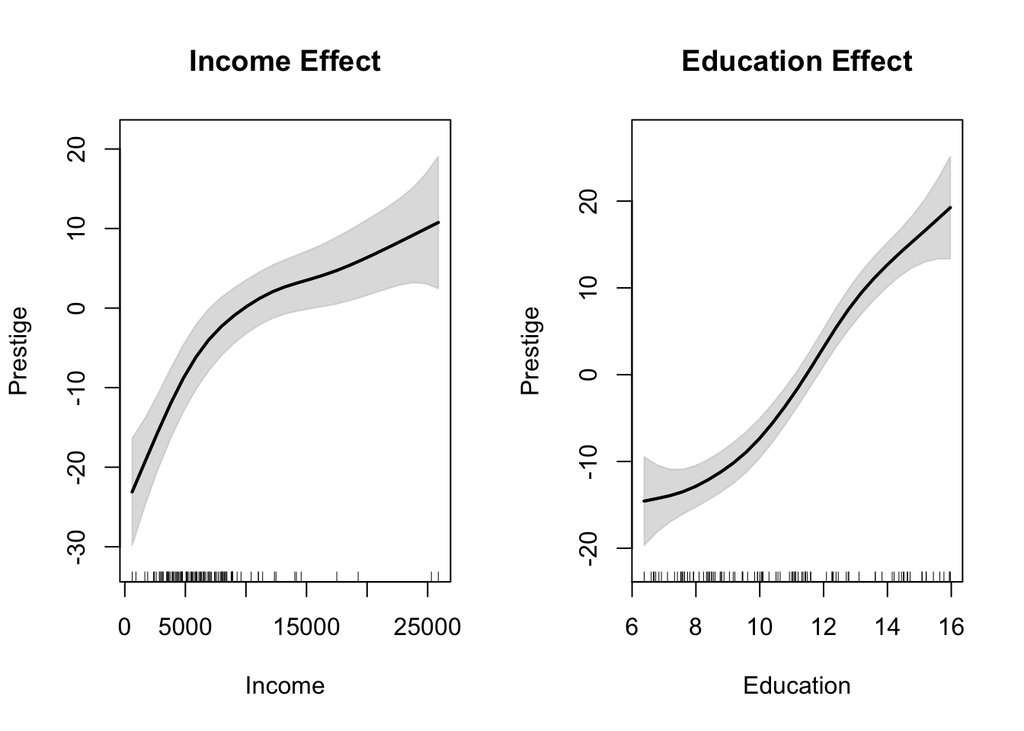

```r
# setup 1 x 2 subplots
par(mfrow = c(1,2))

# get predictor sequences
xrng <- add.gsm$specs$xrng
inc.seq <- seq(xrng$income[1], xrng$income[2], length.out = 25)
edu.seq <- seq(xrng$education[1], xrng$education[2], length.out = 25)

# main effect of income
yhat.inc <- predict(add.gsm, newdata = data.frame(income = inc.seq),
                    se.fit = TRUE, terms = "income")
plotci(inc.seq, yhat.inc$fit, yhat.inc$se.fit,
       xlab = "Income", ylab = "Prestige",
       main = "Income Effect")
rug(Prestige$income)

# main effect of education
yhat.edu <- predict(add.gsm, newdata = data.frame(education = edu.seq),
                    se.fit = TRUE, terms = "education")
plotci(edu.seq, yhat.edu$fit, yhat.edu$se.fit,
       xlab = "Education", ylab = "Prestige",
       main = "Education Effect")
rug(Prestige$education)
```

```r
# setup 2 x 2 subplots
par(mfrow = c(2,2))

# quantiles of education
labs <- c("Low", "Low-Med", "Med-High", "High")
probs <- seq(0.2, 0.8, by = 0.2)
qvals <- unname(quantile(Prestige$education, probs = probs))
qvals
```

```
## [1]  8.128  9.708 11.172 13.620
```

## Example 2: Titanic survival by age and sex

### Overview of the data

The `TitanicSurvival` dataset (from the car package) contains survival and demographic information for n=1309 passengers on the Titanic. We will use a nonparametric logistic regression model to model the probability of survial as a function of age and sex.

First, let’s load the data and visualize the relationship between age (X1), sex (X2), and survival (Y).

```r
data(TitanicSurvival)
head(TitanicSurvival)
```

```
##                                 survived    sex     age passengerClass
## Allen, Miss. Elisabeth Walton        yes female 29.0000            1st
## Allison, Master. Hudson Trevor       yes   male  0.9167            1st
## Allison, Miss. Helen Loraine          no female  2.0000            1st
## Allison, Mr. Hudson Joshua Crei       no   male 30.0000            1st
## Allison, Mrs. Hudson J C (Bessi       no female 25.0000            1st
## Anderson, Mr. Harry                  yes   male 48.0000            1st
```

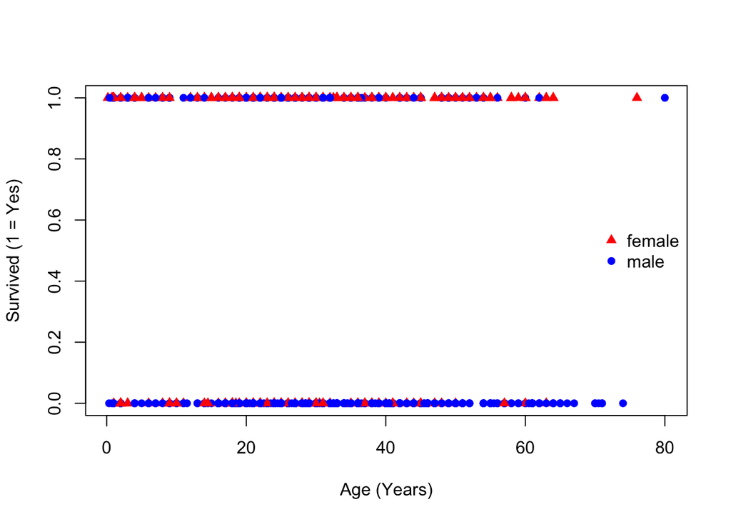

```r
# plot survived ~ age * sex
y <- ifelse(TitanicSurvival$survived == "yes", 1, 0)
plot(TitanicSurvival$age, y,
     xlab = "Age (Years)", ylab = "Survived (1 = Yes)",
     pch = ifelse(TitanicSurvival$sex == "male", 16, 17),
     col = ifelse(TitanicSurvival$sex == "male", "blue", "red"))
legend("right", c("female", "male"), pch = c(17, 16),
       col = c("red", "blue"), bty = "n")
```

### Analyses and Results: gam Function

#### Model Fitting

R code to fit additive and interaction models with gam function:

```r
# additive model
add.gam <- gam(y ~ sex + s(age, bs = "cr"),
               family = binomial, data = TitanicSurvival)
add.gam
```

```
##
## Family: binomial
## Link function: logit
##
## Formula:
## y ~ sex + s(age, bs = "cr")
##
## Estimated degrees of freedom:
## 6.91  total = 8.91
##
## UBRE score: 0.04974017
```

```r
# interaction model
int.gam <- gam(y ~ sex + s(age, bs = "cr", by = sex),
               family = binomial, data = TitanicSurvival)
int.gam
```

```
##
## Family: binomial
## Link function: logit
##
## Formula:
## y ~ sex + s(age, bs = "cr", by = sex)
##
## Estimated degrees of freedom:
## 1.00 6.98  total = 9.98
##
## UBRE score: 0.02615761
```

#### Model Summary

R code to summarize the fit models:

```r
# summarize additive model
summary(add.gam)
```

```
##
## Family: binomial
## Link function: logit
##
## Formula:
## y ~ sex + s(age, bs = "cr")
##
## Parametric coefficients:
##             Estimate Std. Error z value Pr(>|z|)
## (Intercept)   1.1228     0.1191   9.425   <2e-16 ***
## sexmale      -2.4907     0.1549 -16.075   <2e-16 ***
## ---
## Signif. codes:  0 '***' 0.001 '**' 0.01 '*' 0.05 '.' 0.1 ' ' 1
##
## Approximate significance of smooth terms:
##          edf Ref.df Chi.sq p-value
## s(age) 6.911  7.976  18.38   0.016 *
## ---
## Signif. codes:  0 '***' 0.001 '**' 0.01 '*' 0.05 '.' 0.1 ' ' 1
##
## R-sq.(adj) =  0.302   Deviance explained = 23.6%
## UBRE = 0.04974  Scale est. = 1         n = 1046
```

```r
# summarize interaction model
summary(int.gam)
```

```
##
## Family: binomial
## Link function: logit
##
## Formula:
## y ~ sex + s(age, bs = "cr", by = sex)
##
## Parametric coefficients:
##             Estimate Std. Error z value Pr(>|z|)
## (Intercept)   1.1662     0.1226   9.515   <2e-16 ***
## sexmale      -2.5622     0.1590 -16.112   <2e-16 ***
## ---
## Signif. codes:  0 '***' 0.001 '**' 0.01 '*' 0.05 '.' 0.1 ' ' 1
##
## Approximate significance of smooth terms:
##                    edf Ref.df Chi.sq  p-value
## s(age):sexfemale 1.000  1.001  6.958  0.00835 **
## s(age):sexmale   6.979  8.030 36.329 8.79e-06 ***
## ---
## Signif. codes:  0 '***' 0.001 '**' 0.01 '*' 0.05 '.' 0.1 ' ' 1
##
## R-sq.(adj) =   0.32   Deviance explained = 25.5%
## UBRE = 0.026158  Scale est. = 1         n = 1046
```

#### Model Comparison

Compare additive and interaction models:

```r
# pseudo Chisq test of interaction effect
sse.dif <- add.gam$deviance - int.gam$deviance
df.dif <- sum(int.gam$edf1) - sum(add.gam$edf1)
pvalue <- 1 - pchisq(sse.dif, df = df.dif)
c(sse.dif, pvalue)
```

```
## [1] 2.680526e+01 2.547716e-07
```

```r
# analysis of deviance table (gam)
anova(add.gam, int.gam, test = "Chisq")
```

```
## Analysis of Deviance Table
##
## Model 1: y ~ sex + s(age, bs = "cr")
## Model 2: y ~ sex + s(age, bs = "cr", by = sex)
##   Resid. Df Resid. Dev     Df Deviance  Pr(>Chi)
## 1      1036     1080.2
## 2      1035     1053.4 1.0544   26.805 2.548e-07 ***
## ---
## Signif. codes:  0 '***' 0.001 '**' 0.01 '*' 0.05 '.' 0.1 ' ' 1
```

#### Plot Results

Plot results for additive and interaction models:

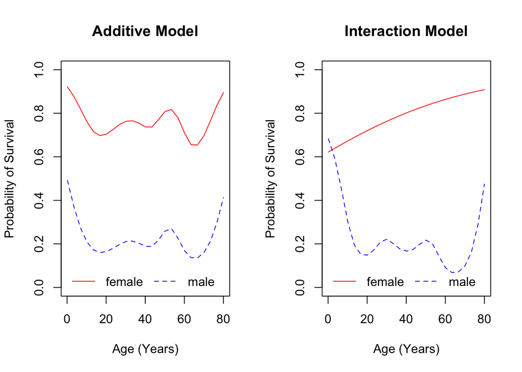

```r
# get predictions (for visualization)
xrng <- list(age = range(TitanicSurvival$age, na.rm = TRUE))
age.seq <- seq(xrng$age[1], xrng$age[2], length.out = 25)
sex.seq <- c("female", "male")
newdata <- expand.grid(age = age.seq, sex = sex.seq)
yhat.add <- predict(add.gam, newdata, type = "response")
yhat.int <- predict(int.gam, newdata, type = "response")

# additive model
par(mfrow = c(1,2))
plot(age.seq, yhat.add[1:25], ylim = c(0, 1), t = "l", col = "red",
     xlab = "Age (Years)", ylab = "Probability of Survival",
     main = "Additive Model")
lines(age.seq, yhat.add[1:25 + 25], lty = 2, col = "blue")
legend("bottomleft", legend = c("female", "male"), lty = 1:2,
       col = c("red", "blue"), horiz = TRUE, bty = "n")

# interaction model
plot(age.seq, yhat.int[1:25], ylim = c(0, 1), t = "l", col = "red",
     xlab = "Age (Years)", ylab = "Probability of Survival",
     main = "Interaction Model")
lines(age.seq, yhat.int[1:25 + 25], lty = 2, col = "blue")
legend("bottomleft", legend = c("female", "male"), lty = 1:2,
       col = c("red", "blue"), horiz = TRUE, bty = "n")
```

### Analyses and Results: gsm Function

####Model Fitting

R code to fit additive and interaction models with gsm function:

```r
# select knots (age quantiles by sex)
probs <- seq(0, 1, length.out = 9)
knots <- with(TitanicSurvival, tapply(age, sex, quantile, probs = probs, na.rm = T))
knots <- list(age = unlist(knots), sex = rep(c("female", "male"), each = 9))
#knots <- list(age = quantile(TitanicSurvival$age, probs = probs, na.rm = TRUE),
#              sex = c("female", "male"))

# additive model
add.gsm <- gsm(y ~ age + sex, family = binomial,
               data = TitanicSurvival, knots = knots)
add.gsm
```

```
##
## Call:
## gsm(formula = y ~ age + sex, family = binomial, data = TitanicSurvival,
##     knots = knots)
##
## Smoothing Parameter:  spar = 0.6554119   lambda = 0.003239272
## Equivalent Degrees of Freedom (Df):  9.723164
## Penalized Criterion (deviance):  1078.102
## Generalized Cross-Validation (GCV):  0.5245551
```

```r
# interaction model
int.gsm <- gsm(y ~ age * sex, family = binomial,
               data = TitanicSurvival, knots = knots)
int.gsm
```

```
##
## Call:
## gsm(formula = y ~ age * sex, family = binomial, data = TitanicSurvival,
##     knots = knots)
##
## Smoothing Parameter:  spar = 0.6088316   lambda = 0.001492511
## Equivalent Degrees of Freedom (Df):  9.023688
## Penalized Criterion (deviance):  1062.67
## Generalized Cross-Validation (GCV):  0.5165595
```

####Model Summary

R code to summarize the fit models:

```r
# summarize additive model
summary(add.gsm)
```

```
##
## Call:
## gsm(formula = y ~ age + sex, family = binomial, data = TitanicSurvival,
##     knots = knots)
##
## Residuals:
##     Min      1Q  Median      3Q     Max
## -2.1924 -0.6839 -0.6077  0.7891  1.9287
##
## Approx. Signif. of Parametric Effects:
##             Estimate Std. Error  z value Pr(>|z|)
## (Intercept) -0.07714     0.1608 -0.47966   0.6315
## age         -0.14833     1.4976 -0.09904   0.9211
## ---
## Signif. codes:  0 '***' 0.001 '**' 0.01 '*' 0.05 '.' 0.1 ' ' 1
##
## Approx. Signif. of Nonparametric Effects:
##                 Df  Chi Sq p.value
## s(age)       6.755   15.93 0.02239   *
## s(sex)       1.006  250.36 0.00000 ***
## Residuals 1036.277 1078.10
## ---
## Signif. codes:  0 '***' 0.001 '**' 0.01 '*' 0.05 '.' 0.1 ' ' 1
##
## Dispersion Parameter: 1,   Deviance Explained: 0.2379
##   Multiple R-squared: 0.309,   Adjusted R-squared: 0.3031
```

```r
# summarize interaction model
summary(int.gsm)
```

```
##
## Call:
## gsm(formula = y ~ age * sex, family = binomial, data = TitanicSurvival,
##     knots = knots)
##
## Residuals:
##     Min      1Q  Median      3Q     Max
## -1.9217 -0.6483 -0.6253  0.7849  1.9419
##
## Approx. Signif. of Parametric Effects:
##             Estimate Std. Error z value Pr(>|z|)
## (Intercept) -0.03578     0.1626 -0.2201   0.8258
## age         -0.66317     1.0636 -0.6235   0.5329
## ---
## Signif. codes:  0 '***' 0.001 '**' 0.01 '*' 0.05 '.' 0.1 ' ' 1
##
## Approx. Signif. of Nonparametric Effects:
##                  Df   Chi Sq  p.value
## s(age)        2.908    6.434 0.086450   .
## s(sex)        3.426  249.238 0.000000 ***
## s(age:sex)    5.907   19.488 0.003188  **
## Residuals  1036.976 1062.670
## ---
## Signif. codes:  0 '***' 0.001 '**' 0.01 '*' 0.05 '.' 0.1 ' ' 1
##
## Dispersion Parameter: 1,   Deviance Explained: 0.2488
##   Multiple R-squared: 0.3203,   Adjusted R-squared: 0.3149
```

####Model Comparison

Compare additive and interaction models:

```r
# pseudo Chisq test of interaction effect
sse.dif <- add.gsm$deviance - int.gsm$deviance
df.dif <- int.gsm$df - add.gsm$df
pvalue <- 1 - pchisq(sse.dif, df = df.dif)
c(sse.dif, pvalue)
```

```
## [1] 15.43197      NaN
```

```r
# df.dif is negative, so set df.dif = 1
pvalue <- 1 - pchisq(sse.dif, df = 1)
c(sse.dif, pvalue)
```

```
## [1] 1.543197e+01 8.552918e-05
```

####Plot Results

Plot results for additive and interaction models:

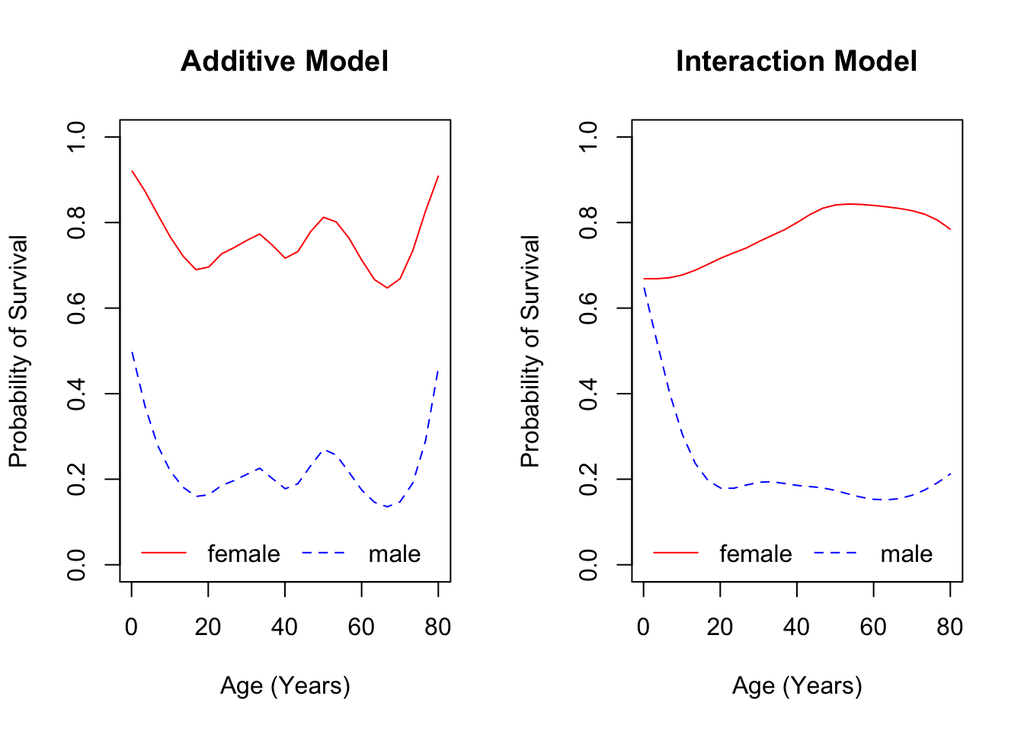

```r
# get predictions (for visualization)
xrng <- add.gsm$specs$xrng
age.seq <- seq(xrng$age[1], xrng$age[2], length.out = 25)
sex.seq <- c("female", "male")
newdata <- expand.grid(age = age.seq, sex = sex.seq)
yhat.add <- predict(add.gsm, newdata, type = "response")
yhat.int <- predict(int.gsm, newdata, type = "response")

# additive model
par(mfrow = c(1,2))
plot(age.seq, yhat.add[1:25], ylim = c(0, 1), t = "l", col = "red",
     xlab = "Age (Years)", ylab = "Probability of Survival",
     main = "Additive Model")
lines(age.seq, yhat.add[1:25 + 25], lty = 2, col = "blue")
legend("bottomleft", legend = c("female", "male"), lty = 1:2,
       col = c("red", "blue"), horiz = TRUE, bty = "n")

# interaction model
plot(age.seq, yhat.int[1:25], ylim = c(0, 1), t = "l", col = "red",
     xlab = "Age (Years)", ylab = "Probability of Survival",
     main = "Interaction Model")
lines(age.seq, yhat.int[1:25 + 25], lty = 2, col = "blue")
legend("bottomleft", legend = c("female", "male"), lty = 1:2,
       col = c("red", "blue"), horiz = TRUE, bty = "n")
```